# Exploratory Data Analysis (EDA) - project example

Martin Frigaard

# Intro

This R Markdown document template for your exploratory data analysis project. You’ve selected (or you’ve been assigned) a dataset, and you’re going to use this template to import, wrangle, visualize and communicate the contents of your data.

# Background

You should have your project set up using the [goodenuffR package](https://github.com/mjfrigaard/goodenuffR). If you haven’t, install this package using the code below:

```r
install.packages("devtools")# for install_github()
library(devtools) # load devtools
devtools::install_github("mjfrigaard/goodenuffR") # install goodenuffR
library(goodenuffR) # load goodenuffR
```

Recall you can use the `goodenuffR` functions to create specific files in your project:

```r
goodenuffR::goodenuff_code() # create code/ folder and files
goodenuffR::goodenuff_data() # create data/ folder and data/raw folder
goodenuffR::goodenuff_doc() # create documentation files
goodenuffR::goodenuff_results() # create results folder
goodenuffR::goodenuff_collab() # create CITATION, requirements, etc.
```

Let’s get started!

# Packages

The packages below have been covered in the course slides and exercises. You’re not required to know all the details of every package (we can look that up), but you *do* need to know how to install a package.

```r
library(tidyverse) # for dplyr, tidyr, ggplot2 and others
library(janitor) # for names
library(skimr) # basic data summaries
```

# Import

Use the code chunk below to import your data into RStudio. The example we will use is from [this pudding article](https://pudding.cool/2019/05/people-map/), “A People Map of the US.”

```r
# this will import data in a .csv file, other options include readxl and
# googlesheets4, and vroom
PeopleMapRaw <- readr::read_csv(file = "https://bit.ly/3mBWNsd")
```

# Dimensions and structure

We will start by asking some general questions about the dataset structure and shape.

## How many columns?

```r
ncol(PeopleMapRaw)
```

```
## [1] 11
```

You can also use `length()`

```r
length(PeopleMapRaw)
```

```
## [1] 11
```

## How many rows?

To simply print the number of rows in your dataset, you can use `nrow()`

```r
nrow(PeopleMapRaw)
```

```
## [1] 9375
```

We can also kill two birds with one stone (columns and rows) using `dim()`

```r
dim(PeopleMapRaw)
```

```
## [1] 9375   11
```

## Variable names?

To get the names assigned to any R data object, you can use the `names()` argument.

```r
names(PeopleMapRaw)
```

```
##  [1] "name"         "city"         "neighborhood" "place"        "views_median"
##  [6] "views_sum"    "name_clean"   "lat"          "lng"          "extract"
## [11] "state"
```

Since we’re using a `tibble` (or `data.frame`), it has columns, and we can use the `colnames()` function.

```r
colnames(PeopleMapRaw)
```

```
##  [1] "name"         "city"         "neighborhood" "place"        "views_median"
##  [6] "views_sum"    "name_clean"   "lat"          "lng"          "extract"
## [11] "state"
```

## Variable formats?

```r
str(PeopleMapRaw)
```

```
## spec_tbl_df [9,375 × 11] (S3: spec_tbl_df/tbl_df/tbl/data.frame)
##  $ name        : chr [1:9375] "Donald Trump" "Donald Trump" "Cardi B" "Cardi B" ...
##  $ city        : chr [1:9375] "Bedminster" "New York City" "Edgewater" "Bronx" ...
##  $ neighborhood: chr [1:9375] NA NA NA NA ...
##  $ place       : chr [1:9375] "Bedminster" "New York City" "Edgewater" "Bronx" ...
##  $ views_median: num [1:9375] 53319 53181 31791 31567 27307 ...
##  $ views_sum   : num [1:9375] 140255718 140641448 28729507 29101434 42213949 ...
##  $ name_clean  : chr [1:9375] "Donald Trump" "Donald Trump" "Cardi B" "Cardi B" ...
##  $ lat         : num [1:9375] 40.7 40.7 40.8 40.8 26.1 ...
##  $ lng         : num [1:9375] -74.7 -74 -74 -73.9 -80.3 ...
##  $ extract     : chr [1:9375] "Donald John Trump is the 45th and current president of the United States. Before entering politics, he was a bu"| __truncated__ "Donald John Trump is the 45th and current president of the United States. Before entering politics, he was a bu"| __truncated__ "Belcalis…
##  $ state       : chr [1:9375] "New Jersey" "New York" "New Jersey" "New York" ...
##  - attr(*, "spec")=
##   .. cols(
##   ..   name = col_character(),
##   ..   city = col_character(),
##   ..   neighborhood = col_character(),
##   ..   place = col_character(),
##   ..   views_median = col_double(),
##   ..   views_sum = col_double(),
##   ..   name_clean = col_character(),
##   ..   lat = col_double(),
##   ..   lng = col_double(),
##   ..   extract = col_character(),
##   ..   state = col_character()
##   .. )
##  - attr(*, "problems")=<externalptr>
```

```r
glimpse(PeopleMapRaw)
```

```
## Rows: 9,375
## Columns: 11
## $ name         <chr> "Donald Trump", "Donald Trump", "Cardi B", "Cardi B", "…
## $ city         <chr> "Bedminster", "New York City", "Edgewater", "Bronx", "S…
## $ neighborhood <chr> NA, NA, NA, NA, NA, NA, NA, NA, NA, NA, "Bushwick", NA,…
## $ place        <chr> "Bedminster", "New York City", "Edgewater", "Bronx", "S…
## $ views_median <dbl> 53319.0, 53181.0, 31791.0, 31567.0, 27307.0, 27277.0, 2…
## $ views_sum    <dbl> 140255718, 140641448, 28729507, 29101434, 42213949, 425…
## $ name_clean   <chr> "Donald Trump", "Donald Trump", "Cardi B", "Cardi B", "…
## $ lat          <dbl> 40.66926, 40.71278, 40.82704, 40.84478, 26.05870, 37.66…
## $ lng          <dbl> -74.68040, -74.00597, -73.97569, -73.86483, -80.33727, …
## $ extract      <chr> "Donald John Trump is the 45th and current president of…
## $ state        <chr> "New Jersey", "New York", "New Jersey", "New York", "Fl…
```

## Export raw data

Now that we know our data imported correctly, we can export an example of these data to the `data/raw/` folder.

```r
fs::dir_create("data/raw/")
out_path <- paste0("data/raw/", noquote(lubridate::today()), "-PeopleMapRaw.csv")
write_csv(x = PeopleMapRaw, file = out_path)
# verify
fs::dir_tree("data/raw/")
```

```
## data/raw/
## ├── 2021-10-30-PeopleMapRaw.csv
## └── 2021-10-31-PeopleMapRaw.csv
```

# Wrangle

The first thing we want to do with `PeopleMapRaw` is standardize the column names and make sure they’re meaningful, then we want to check the contents of each variable.

## Column names

The janitor package has a great function for dealing with column names, `janitor::clean_names()`. This function automatically converts all names to `lower_snake_case`, which makes them easier to read and program with.

In `PeopleMapRaw`, the names are already in `lower_snake_case`, but we’ll apply `clean_names()` just because it’s a good habit to get into.

```r
PeopleMap <- janitor::clean_names(PeopleMapRaw)
glimpse(PeopleMap)
```

```
## Rows: 9,375
## Columns: 11
## $ name         <chr> "Donald Trump", "Donald Trump", "Cardi B", "Cardi B", "…
## $ city         <chr> "Bedminster", "New York City", "Edgewater", "Bronx", "S…
## $ neighborhood <chr> NA, NA, NA, NA, NA, NA, NA, NA, NA, NA, "Bushwick", NA,…
## $ place        <chr> "Bedminster", "New York City", "Edgewater", "Bronx", "S…
## $ views_median <dbl> 53319.0, 53181.0, 31791.0, 31567.0, 27307.0, 27277.0, 2…
## $ views_sum    <dbl> 140255718, 140641448, 28729507, 29101434, 42213949, 425…
## $ name_clean   <chr> "Donald Trump", "Donald Trump", "Cardi B", "Cardi B", "…
## $ lat          <dbl> 40.66926, 40.71278, 40.82704, 40.84478, 26.05870, 37.66…
## $ lng          <dbl> -74.68040, -74.00597, -73.97569, -73.86483, -80.33727, …
## $ extract      <chr> "Donald John Trump is the 45th and current president of…
## $ state        <chr> "New Jersey", "New York", "New Jersey", "New York", "Fl…
```

Notice I changed the name of `PeopleMapRaw` to `PeopleMap` because we’ve altered the contents of the raw data (and we want to keep these separate).

## Summary statistics

We’re not going to dive too deep into statistical topics, but we do need to know how to calculate some summary statistics.

The simplest way to calculate summary statistics for the `PeopleMap` data is to apply the `skimr::skim()` function.

```r
skimr::skim(PeopleMap)
```

Data summary

| Name | PeopleMap |
| --- | --- |
| Number of rows | 9375 |
| Number of columns | 11 |
| _______________________ |  |
| Column type frequency: |  |
| character | 7 |
| numeric | 4 |
| ________________________ |  |
| Group variables | None |

**Variable type: character**

| skim_variable | n_missing | complete_rate | min | max | empty | n_unique | whitespace |
| --- | --- | --- | --- | --- | --- | --- | --- |
| name | 0 | 1.00 | 3 | 44 | 0 | 8497 | 0 |
| city | 0 | 1.00 | 3 | 26 | 0 | 6406 | 0 |
| neighborhood | 9227 | 0.02 | 4 | 23 | 0 | 148 | 0 |
| place | 0 | 1.00 | 3 | 26 | 0 | 6512 | 0 |
| name_clean | 0 | 1.00 | 2 | 44 | 0 | 8465 | 0 |
| extract | 3 | 1.00 | 32 | 203 | 0 | 8500 | 0 |
| state | 6 | 1.00 | 4 | 18 | 0 | 93 | 0 |

**Variable type: numeric**

| skim_variable | n_missing | complete_rate | mean | sd | p0 | p25 | p50 | p75 | p100 | hist |
| --- | --- | --- | --- | --- | --- | --- | --- | --- | --- | --- |
| views_median | 0 | 1 | 1099.82 | 2593.46 | 0.00 | 28.00 | 166.00 | 906.00 | 53319.00 | ▇▁▁▁▁ |
| views_sum | 19 | 1 | 1985089.24 | 4785846.96 | 300.00 | 46660.00 | 303412.00 | 1724726.25 | 140641448.00 | ▇▁▁▁▁ |
| lat | 0 | 1 | 39.21 | 4.78 | 19.64 | 35.79 | 40.42 | 42.57 | 71.29 | ▁▇▇▁▁ |
| lng | 0 | 1 | -88.08 | 14.52 | -166.53 | -94.37 | -85.34 | -76.45 | -66.98 | ▁▁▂▅▇ |

We should inspect this output for anything that looks out of the ordinary. For example, we can see `state` lists 93 unique values. This isn’t possible, so we should check this variable with `count()`

```r
PeopleMap %>%
  count(state, sort = TRUE)
```

| state | n |
| --- | --- |
| New York | 823 |
| California | 526 |
| Texas | 463 |
| Wisconsin | 422 |
| Illinois | 419 |
| Ohio | 404 |
| New Jersey | 362 |
| Massachusetts | 352 |
| Michigan | 265 |
| Florida | 259 |

[output cut: 84 more lines]

We can see this is including more than just the states (counties too). We’re going to wrangle the state to `state_name` (and not remove any of the other information in state).

R comes with a vector `state.name` which contains all 50 state names.

```r
state.name
```

```
##  [1] "Alabama"        "Alaska"         "Arizona"        "Arkansas"
##  [5] "California"     "Colorado"       "Connecticut"    "Delaware"
##  [9] "Florida"        "Georgia"        "Hawaii"         "Idaho"
## [13] "Illinois"       "Indiana"        "Iowa"           "Kansas"
## [17] "Kentucky"       "Louisiana"      "Maine"          "Maryland"
## [21] "Massachusetts"  "Michigan"       "Minnesota"      "Mississippi"
## [25] "Missouri"       "Montana"        "Nebraska"       "Nevada"
## [29] "New Hampshire"  "New Jersey"     "New Mexico"     "New York"
## [33] "North Carolina" "North Dakota"   "Ohio"           "Oklahoma"
## [37] "Oregon"         "Pennsylvania"   "Rhode Island"   "South Carolina"
## [41] "South Dakota"   "Tennessee"      "Texas"          "Utah"
## [45] "Vermont"        "Virginia"       "Washington"     "West Virginia"
## [49] "Wisconsin"      "Wyoming"
```

We’ll convert this to a regular expression.

```r
# get a regular expression for state names
state_pattern <- paste0(state.name, collapse = "|")
state_pattern
```

```
## [1] "Alabama|Alaska|Arizona|Arkansas|California|Colorado|Connecticut|Delaware|Florida|Georgia|Hawaii|Idaho|Illinois|Indiana|Iowa|Kansas|Kentucky|Louisiana|Maine|Maryland|Massachusetts|Michigan|Minnesota|Mississippi|Missouri|Montana|Nebraska|Nevada|New Hampshire|New Jersey|New Mexico|New York|Nort…
```

We’ll use `state_pattern` to filter the states in the state column to only *actual* states, then count the two variables to see if there are any valuess that were missed.

```r
PeopleMap %>%
  mutate(
  state_name = case_when(
    str_detect(state, state_pattern) ~ state,
    TRUE ~ NA_character_)) %>%
    count(state_name, state) %>%
    filter(!is.na(state_name)) %>%
    arrange(n)
```

| state_name | state | n |
| --- | --- | --- |
| Iowa County | Iowa County | 1 |
| Washington County | Washington County | 1 |
| Hawaii | Hawaii | 8 |
| North Dakota | North Dakota | 15 |
| Alaska | Alaska | 22 |
| Nevada | Nevada | 26 |
| Delaware | Delaware | 28 |
| Rhode Island | Rhode Island | 35 |
| Wyoming | Wyoming | 38 |
| New Mexico | New Mexico | 41 |

[output cut: 42 more lines]

We will add the `Iowa County` and `Washington County` to the mutate function (to properly categorize the counties as `NA`)

```r
PeopleMap %>%
  mutate(
  state_name = case_when(
    str_detect(state, state_pattern) ~ state,
    TRUE ~ NA_character_),
  # include the counties
  state_name = case_when(
     state_name == "Iowa County" ~ NA_character_,
     state_name == "Washington County" ~ NA_character_,
     TRUE ~ state_name)) %>%
  count(state_name, state) %>%
  filter(!is.na(state_name)) %>%
  arrange(n)
```

| state_name | state | n |
| --- | --- | --- |
| Hawaii | Hawaii | 8 |
| North Dakota | North Dakota | 15 |
| Alaska | Alaska | 22 |
| Nevada | Nevada | 26 |
| Delaware | Delaware | 28 |
| Rhode Island | Rhode Island | 35 |
| Wyoming | Wyoming | 38 |
| New Mexico | New Mexico | 41 |
| Montana | Montana | 55 |
| Arizona | Arizona | 63 |

[output cut: 40 more lines]

Now we will create a state_abbr (state abbreviation) variable based on our new `state_name` variable using the `state2abbr()` from the [`usdata` package](https://openintrostat.github.io/usdata/index.html).

```r
# install.packages("usdata")
library(usdata)
PeopleMap <- PeopleMap %>%
  mutate(
  state_name = case_when(
    str_detect(state, state_pattern) ~ state,
    TRUE ~ NA_character_),
  # include the counties
  state_name = case_when(
     state_name == "Iowa County" ~ NA_character_,
     state_name == "Washington County" ~ NA_character_,
     TRUE ~ state_name),
  state_abbr = usdata::state2abbr(state = state_name))
PeopleMap %>%
  select(state, state_name, state_abbr) %>% head()
```

| state | state_name | state_abbr |
| --- | --- | --- |
| New Jersey | New Jersey | NJ |
| New York | New York | NY |
| New Jersey | New Jersey | NJ |
| New York | New York | NY |
| Florida | Florida | FL |
| California | California | CA |

```r
PeopleMap %>%
  select(state, state_name, state_abbr) %>% tail()
```

| state | state_name | state_abbr |
| --- | --- | --- |
| Wisconsin | Wisconsin | WI |
| Vermont | Vermont | VT |
| Fond du Lac County | NA | NA |
| Vermont | Vermont | VT |
| Vermont | Vermont | VT |
| Vermont | Vermont | VT |

# Visualizations

We’re going to create a few exploratory graphs of the variables in our imported data. From the `skim()` output, we can see there are four numerical variables and seven character variables.

## Single variable graphs

We’re going to start with some graphs of the numerical variable, `views_median`.

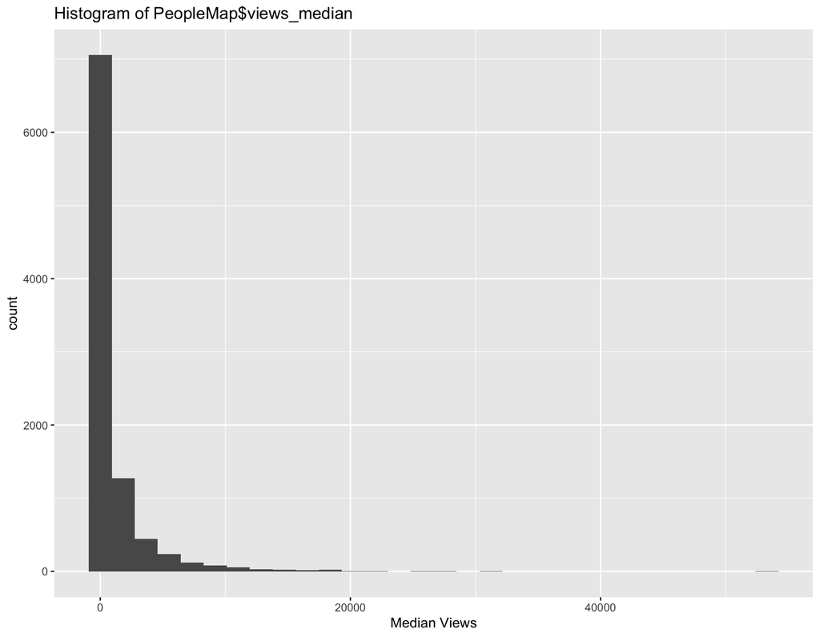

```r
# label
labs_hist <- labs(title = "Histogram of PeopleMap$views_median",
                  x = "Median Views")
PeopleMap %>%
  ggplot(aes(x = views_median)) +
    geom_histogram() +
      labs_hist
```

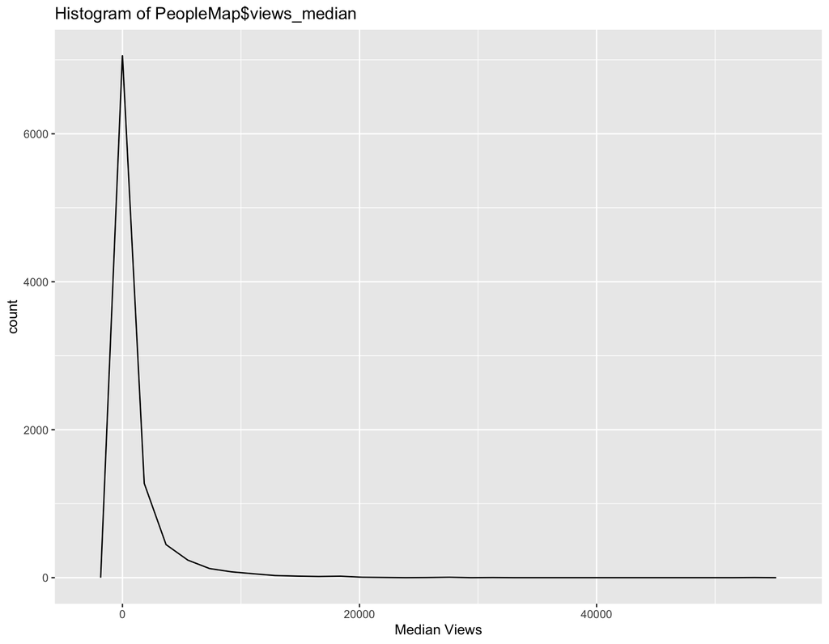

```r
# label
labs_freq <- labs(title = "Histogram of PeopleMap$views_median",
                  x = "Median Views")
PeopleMap %>%
  ggplot(aes(x = views_median)) +
    geom_freqpoly() +
      labs_freq
```

## Multiple variable graphs

We’re going to see how `views_median` looks across the `state_name` variable.

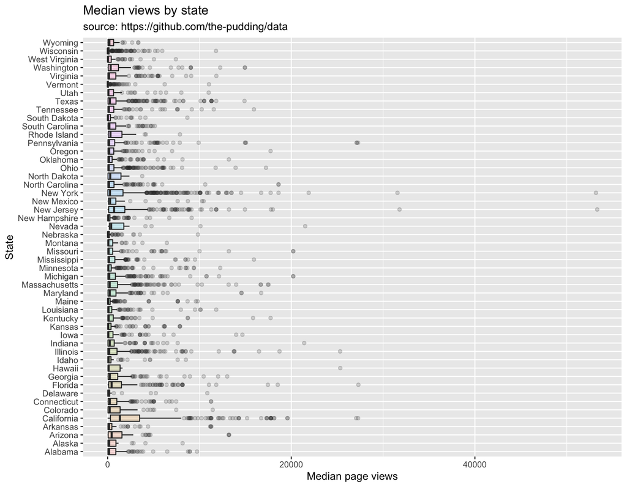

```r
labs_box2 <- labs(
     title = "Median views by state",
     subtitle = "source: https://github.com/the-pudding/data",
     fill = "State",
     x = "Median page views",
     y = "State")
PeopleMap %>%
  # remove missing states
  filter(!is.na(state_name)) %>%
  ggplot() +
  geom_boxplot(aes(x = views_median,
                      y = state_name,
                      fill = state_name),
                      alpha = 1/5,
               show.legend = FALSE) +
  labs_box2
```

The graph above makes it hard to see the difference between states, so we can use the `facet_wrap()` function by setting the `group` aesthetic to our new `state_name` variable.

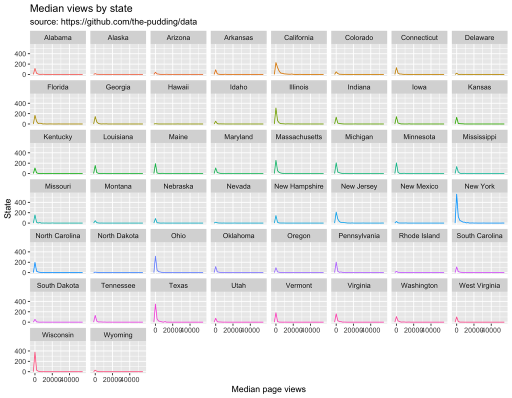

```r
labs_freq2 <- labs(
     title = "Median views by state",
     subtitle = "source: https://github.com/the-pudding/data",
     fill = "State",
     x = "Median page views",
     y = "State")
PeopleMap %>%
  # remove missing states
  filter(!is.na(state_name)) %>%
  ggplot(aes(x = views_median, group = state_name)) +
    geom_freqpoly(aes(color = state_name),
                  show.legend = FALSE) +
    facet_wrap(~ state_name) +
    labs_freq2
```

This is a better way to see which states had more median page views, but we can still improve the graph by using our `state_abbr` variable, the [`geofacet` package](https://hafen.github.io/geofacet/) and black and white theme (`theme_bw()`) from [`ggplot2`](https://ggplot2.tidyverse.org/reference/ggtheme.html).

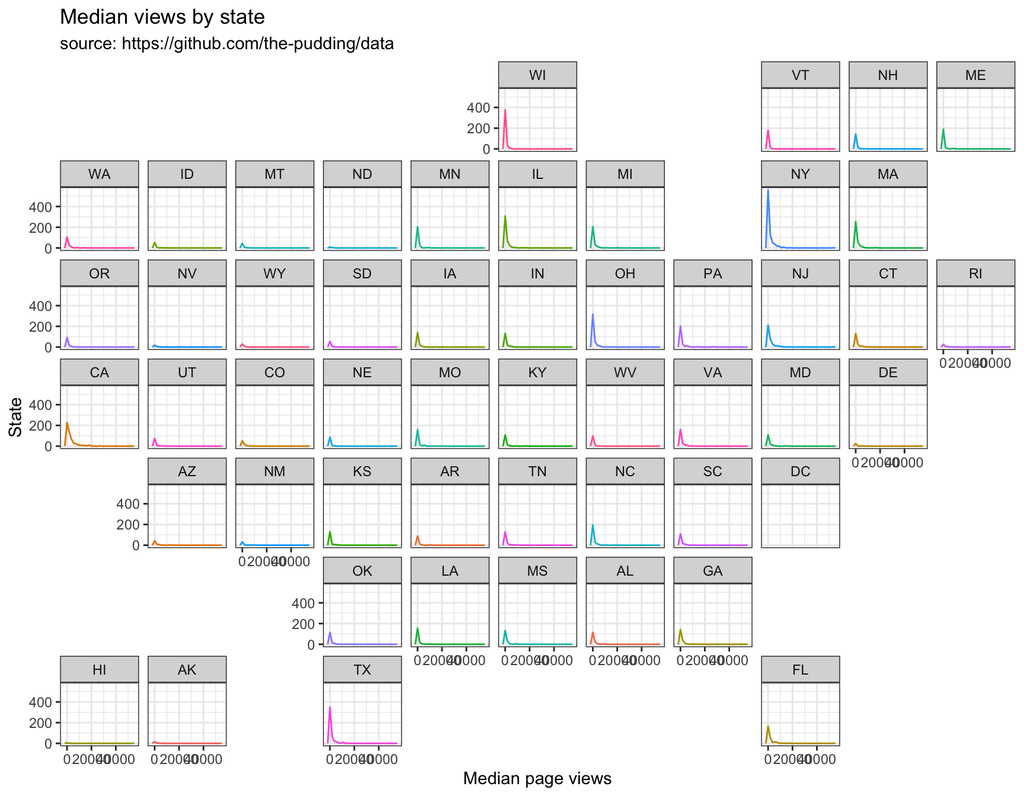

```r
library(geofacet)
PeopleMap %>%
  # remove missing states
  filter(!is.na(state_abbr)) %>%
  ggplot(aes(x = views_median, group = state_abbr)) +
    geom_freqpoly(aes(color = state_abbr),
                  show.legend = FALSE) +
    facet_geo(~ state_abbr) +
  theme_bw() +
  labs_freq2
```

# Data dictionary

We want to include a data dictionary with this dataset, which we can find in the [README.md file](https://github.com/the-pudding/data/blob/master/people-map/README.md) on the Github page.

## Example

> This folder contains all of the data used in The Pudding essay A People Map of the US published in May 2019.

> The data will never be updated.

> Below you’ll find the metadata for each file.

### people-map.csv

> - **What is this?**: Data of the most visited person(s) Wikipedia page for each city with a “List of People from…” (~ 10,000) in the US
> - **Source(s) & Methodology**: [English Wikipedia](https://en.wikipedia.org)
> - **Last Modified**: May 2019
> - **Contact Information**: Russell Goldenberg
> - **Spatial Applicability**: United States
> - **Temporal Applicability**: July 2015 through May 2019
> - **Observations (Rows)**: Each row represents one person.
> - **Variables (Columns)**:

| Header | Description | Data Type |
| --- | --- | --- |
| `name` | name of person | text |
| `city` | city/town name | text |
| `neighborhood` | neighborhood name (if applicable) | text |
| `place` | neighborhood or city | text |
| `views_median` | average number of pageviews per day | number |
| `views_sum` | total number of pageviews | number |
| `name_clean` | display name (removed items in parenthesis) | text |
| `lat` | latitude of place | number |
| `lng` | longitude of place | number |
| `extract` | 200 character description of person | text |
| `state` | state (or sometimes county if state is NA) | text |
| `state_name` | state name | text |
| `state_abbr` | state abbreviated name | text |